# MLB Batting Order Simulation, 2023-2026

Math 534 Project

2026-11-19

# 1 Overview

**Question.** With the same nine hitters, does a Traditional batting order (A) or an OPS-ranked order (B) produce more expected runs? Five teams (Dodgers, Cubs, Cardinals, Angels, Giants), 2023-2026 regular seasons, 20 team-seasons.

**Key results.** The two orders give practically the same expected runs in all 20 team-seasons. In 2 team-seasons the rules produce the identical lineup. In the other 18, B minus A ranges from −0.006 to +0.020 runs per game, or −1 to +3 runs over 162 games. Across team-seasons the mean difference is 0.0015 runs per game (95% CI −0.0014 to 0.0045, *p* = 0.30). Reversing a lineup costs 0.06-0.19 runs per game, so the model does respond to order; A and B are simply too similar. The result holds under the PM notebook’s choices (same-season statistics, fixed base-running rules).

**Pipeline.** This file runs every step, in order:

1. **Data collection.** Play-by-play for every regular-season game of the five teams, official player and team statistics, all from the MLB Stats API.
2. **Cleaning and checks.** Each team-season’s play-by-play counts must match its official totals.
3. **Two clean tables** replace the supplied workbooks: player statistics and player outcome probabilities for 2023-2026 (`clean/`). A section compares them with the supplied files.
4. **Hitters and orders.** Each team-season’s nine regulars. Orders A and B follow the scope’s rules, using each hitter’s **previous-season** OBP, SLG, and OPS, which is what a manager knows before the season.
5. **Simulation model.** Each hitter’s outcome rates for that season and base-out transitions estimated from that season’s play-by-play. A Markov chain gives exact expected runs; a Monte Carlo simulation checks it.
6. **Results, model checks, and stability checks.**

To reproduce, Knit in RStudio or run `rmarkdown::render("MLB_Lineup_Simulation.Rmd")`. If `source_cache/` from an earlier run is in the same folder, the Knit runs offline in about 5 minutes. Otherwise the first run downloads about 3,000 game files into `source_cache/`, which needs network access and takes over an hour. The comparison with the supplied workbooks runs only when the two `.xlsx` files are in the same folder.

```r
library(dplyr)
library(tidyr)
knitr::opts_chunk$set(message = FALSE)
for (d in c("source_cache/api/games", "clean", "processed", "quality")) dir.create(d, recursive = TRUE, showWarnings = FALSE)
seasons <- 2023:2026
team_ids <- c(Dodgers = 119, Cubs = 112, Cardinals = 138, Angels = 108, Giants = 137)
api <- "https://statsapi.mlb.com/api/v1"
supplied_files <- c(stats = "Math 534 Baseball Project-2.xlsx", probs = "MLB_2023_2026_5Teams_Player_Probabilities.xlsx")
have_supplied <- all(file.exists(supplied_files))  # the workbook comparison is skipped without them
```

# 2 Data Collection

## 2.1 API Helpers

Every response is saved under `source_cache/` on first use, so later Knits are offline and give the same answer.

```r
get_json <- function(url, file) {
  if (!file.exists(file)) {
    download.file(url, paste0(file, ".part"), quiet = TRUE, mode = "wb")
    file.rename(paste0(file, ".part"), file)
  }
  jsonlite::fromJSON(file, simplifyVector = FALSE)
}
val <- function(x) if (is.null(x)) NA else x  # missing JSON field becomes NA
stat_row <- function(s) data.frame(
  g = val(s$gamesPlayed), pa = s$plateAppearances, ab = s$atBats, r = val(s$runs), h = s$hits, d2 = s$doubles,
  d3 = s$triples, hr = s$homeRuns, rbi = val(s$rbi), bb = s$baseOnBalls, ibb = val(s$intentionalWalks),
  hbp = s$hitByPitch, so = s$strikeOuts, sf = s$sacFlies, sb = val(s$stolenBases), cs = val(s$caughtStealing))

# Season hitting totals for every MLB player (a traded player has one row, all teams combined).
league_hitting <- function(season) {
  url <- paste0(api, "/stats?stats=season&group=hitting&gameType=R&playerPool=ALL&sportIds=1&limit=10000&season=", season)
  bind_rows(lapply(get_json(url, sprintf("source_cache/api/league_%d.json", season))$stats[[1]]$splits, function(p)
    data.frame(season = season, batter_id = as.character(p$player$id), player = p$player$fullName, stat_row(p$stat))))
}

# Season hitting totals for a whole team.
team_hitting <- function(season, team) {
  url <- paste0(api, "/teams/", team_ids[[team]], "/stats?stats=season&group=hitting&gameType=R&season=", season)
  s <- get_json(url, sprintf("source_cache/api/teamtotal_%d_%s.json", season, team))$stats[[1]]$splits[[1]]$stat
  data.frame(season = season, team = team, stat_row(s))
}

# Regular-season games that were played to a final result.
final_games <- function(season, team) {
  url <- paste0(api, "/schedule?sportId=1&gameType=R&season=", season, "&teamId=", team_ids[[team]],
                "&fields=dates,date,games,gamePk,status,abstractGameState,detailedState,teams,away,home,team,id,score")
  d <- get_json(url, sprintf("source_cache/api/sched_%d_%s.json", season, team))
  unlist(lapply(d$dates, function(dt) unlist(lapply(dt$games, function(g)
    if (g$status$abstractGameState == "Final" && !grepl("Postponed|Cancelled|Suspended", g$status$detailedState))
      as.character(g$gamePk)))))
}

# Player records with year-by-year hitting lines, in batches of 100 IDs.
get_people <- function(ids) {
  batches <- split(ids, ceiling(seq_along(ids) / 100))
  unlist(lapply(batches, function(b) {
    url <- paste0(api, "/people?personIds=", paste(b, collapse = ","), "&hydrate=stats(group=[hitting],type=[yearByYear])")
    file <- sprintf("source_cache/api/people_%s_%d.json", b[1], length(b))
    z <- get_json(url, file)$people
    if (!setequal(vapply(z, function(p) as.character(p$id), ""), b)) {  # cached file is for another ID set
      unlink(file)
      z <- get_json(url, file)$people
    }
    z
  }), recursive = FALSE)
}
# Each player's official season line for each of the five teams he played for.
team_splits <- function(people) {
  bind_rows(lapply(people, function(p) {
    splits <- unlist(lapply(p$stats, `[[`, "splits"), recursive = FALSE)
    bind_rows(lapply(splits, function(s) {
      tid <- val(s$team$id)
      if (is.na(tid) || !tid %in% team_ids || !as.integer(s$season) %in% seasons) return(NULL)
      data.frame(season = as.integer(s$season), team = names(team_ids)[match(tid, team_ids)],
                 batter_id = as.character(p$id), player = p$fullName, stat_row(s$stat))
    }))
  }))
}
```

## 2.2 Play-by-Play, 2023-2026

Every regular-season game involving the five teams, both offenses. For each play: the inning, the event, the outs and runners after the play, and the batting team’s score. Each season’s parsed plays are also cached, so a re-Knit does not parse 3,000 files again.

```r
game_fields <- paste(c("gameData", "status", "abstractGameState", "teams", "away", "home", "id", "liveData", "plays",
                       "allPlays", "about", "inning", "halfInning", "result", "eventType", "awayScore", "homeScore",
                       "count", "outs", "matchup", "batter", "postOnFirst", "postOnSecond", "postOnThird"), collapse = ",")
read_plays <- function(g) {
  z <- get_json(paste0("https://statsapi.mlb.com/api/v1.1/game/", g, "/feed/live?fields=", game_fields),
                sprintf("source_cache/api/games/%s.json", g))
  ap <- z$liveData$plays$allPlays
  half <- vapply(ap, function(p) p$about$halfInning, "")
  data.frame(game_id = g, state = z$gameData$status$abstractGameState, play = seq_along(ap),
             batting_team_id = ifelse(half == "top", z$gameData$teams$away$id, z$gameData$teams$home$id),
             inning = vapply(ap, function(p) as.integer(p$about$inning), 1L), half = half,
             batter_id = vapply(ap, function(p) as.character(p$matchup$batter$id), ""),
             event = vapply(ap, function(p) as.character(val(p$result$eventType)), ""),
             outs = vapply(ap, function(p) as.integer(val(p$count$outs)), 1L),
             score = vapply(seq_along(ap), function(i)
               as.numeric(val(ap[[i]]$result[[paste0(if (half[i] == "top") "away" else "home", "Score")]])), 1),
             on1 = vapply(ap, function(p) !is.null(p$matchup$postOnFirst), TRUE),
             on2 = vapply(ap, function(p) !is.null(p$matchup$postOnSecond), TRUE),
             on3 = vapply(ap, function(p) !is.null(p$matchup$postOnThird), TRUE))
}
season_plays <- function(season) {
  ids <- sort(unique(unlist(lapply(names(team_ids), function(t) final_games(season, t)))))
  file <- sprintf("source_cache/plays_%d.rds", season)
  if (file.exists(file)) {
    d <- readRDS(file)
    if (setequal(unique(d$game_id), ids)) return(d)
  }
  d <- bind_rows(lapply(ids, read_plays)) %>% mutate(season = season)
  saveRDS(d, file)
  d
}
raw_plays <- bind_rows(lapply(seasons, season_plays))
raw_plays %>% group_by(season) %>% summarise(games = n_distinct(game_id), plays = n())
```

| season | games | plays |
| --- | --- | --- |
| 2023 | 744 | 56854 |
| 2024 | 745 | 56104 |
| 2025 | 744 | 56047 |
| 2026 | 745 | 56661 |

## 2.3 Official Statistics

```r
league <- bind_rows(lapply(2021:2026, league_hitting))  # 2021-2022 are needed for the 2023 orders
stopifnot(!anyDuplicated(league[c("season", "batter_id")]))
team_totals <- bind_rows(lapply(seasons, function(y) bind_rows(lapply(names(team_ids), function(t) team_hitting(y, t)))))
table(season = league$season)
```

```
## season
## 2021 2022 2023 2024 2025 2026
## 1374  794  769  742  765  751
```

# 3 Cleaning and Checks

## 3.1 Plate-Appearance Outcomes

Eight outcomes. BB includes intentional walks and hit-by-pitch. ROE is reached on error or catcher’s interference. OUT is every other plate appearance: outs in play, double plays, sacrifices, fielder’s choice.

```r
categories <- c("1B", "2B", "3B", "HR", "BB", "ROE", "K", "OUT")
event_category <- c(
  single = "1B", double = "2B", triple = "3B", home_run = "HR",
  walk = "BB", intent_walk = "BB", hit_by_pitch = "BB", field_error = "ROE", catcher_interf = "ROE",
  strikeout = "K", strikeout_double_play = "K", strikeout_triple_play = "K",
  field_out = "OUT", force_out = "OUT", grounded_into_double_play = "OUT", grounded_into_triple_play = "OUT",
  double_play = "OUT", triple_play = "OUT", sac_fly = "OUT", sac_fly_double_play = "OUT", sac_bunt = "OUT",
  sac_bunt_double_play = "OUT", fielders_choice = "OUT", fielders_choice_out = "OUT", batter_interference = "OUT")
# Plays that end without a completed plate appearance; they change the state but are not outcomes.
non_pa_events <- c("caught_stealing_2b", "caught_stealing_3b", "caught_stealing_home", "pickoff_1b", "pickoff_2b",
                   "pickoff_3b", "pickoff_caught_stealing_2b", "pickoff_caught_stealing_3b",
                   "pickoff_caught_stealing_home", "pickoff_error_1b", "pickoff_error_2b", "pickoff_error_3b",
                   "stolen_base_2b", "stolen_base_3b", "stolen_base_home", "wild_pitch", "passed_ball", "balk",
                   "other_advance", "other_out", "runner_double_play", "error", "defensive_indiff")
n_runners <- function(b) b %% 2 + b %/% 2 %% 2 + b %/% 4

plays <- raw_plays %>%
  mutate(category = unname(event_category[event]), is_pa = !is.na(category),
         bases = on1 + 2L * on2 + 4L * on3,
         team = names(team_ids)[match(batting_team_id, team_ids)]) %>%
  group_by(game_id, half) %>% arrange(play, .by_group = TRUE) %>%
  mutate(runs = score - lag(score, default = 0)) %>%
  group_by(game_id, inning, half) %>%
  mutate(pre_outs = lag(outs, default = 0L), pre_bases = lag(bases, default = 0L),
         runs_rest = rev(cumsum(rev(runs))), last_play = row_number() == n()) %>%
  ungroup() %>%
  mutate(used = inning <= 8 | (inning == 9 & half == "top"),
         balanced = outs == 3 |
           n_runners(pre_bases) + is_pa == n_runners(bases) + runs + outs - pre_outs)
table(category = plays$category, useNA = "ifany")
```

```
## category
##     1B     2B     3B     BB     HR      K    OUT    ROE   <NA>
##  31969   9491    825  22090   6931  50159 102246   1427    528
```

`NA` rows are steals, pickoffs, and other plays without a completed plate appearance. `balanced` checks that every runner and the batter is accounted for: runners before plus the batter equal runners after plus runs plus new outs. Only innings 1-8 and the top of the 9th feed the transition model (`used`), because a walk-off can end the bottom of the 9th early and extra innings start with a runner on second.

## 3.2 Play-by-Play Checks

The key check: for every team-season, the play-by-play counts of each outcome equal the team’s official season totals. Official totals do not separate ROE, so ROE and OUT are compared together.

```r
used <- plays %>% filter(used)
official_counts <- function(d) with(d, cbind(`1B` = h - d2 - d3 - hr, `2B` = d2, `3B` = d3, HR = hr, BB = bb + hbp,
                                             K = so, `ROE+OUT` = pa - h - bb - hbp - so))
feed_counts <- plays %>% filter(is_pa, !is.na(team)) %>%
  mutate(category = ifelse(category %in% c("ROE", "OUT"), "ROE+OUT", category)) %>%
  count(season, team, category) %>% pivot_wider(names_from = category, values_from = n) %>%
  arrange(season, team)
team_totals <- team_totals %>% arrange(season, team)
stat_counts <- data.frame(team_totals[c("season", "team")], official_counts(team_totals), check.names = FALSE)
count_cols_check <- colnames(official_counts(team_totals))
unknown_events <- setdiff(unique(plays$event), c(names(event_category), non_pa_events))

play_checks <- plays %>% group_by(season) %>% summarise(
  "All games are final" = all(state == "Final"),
  "Every play is classified" = all(event %in% c(names(event_category), non_pa_events)),
  "Outs never decrease within a half-inning" = all(outs >= pre_outs & outs <= 3),
  "No negative runs" = all(runs >= 0),
  "Innings 1-8 end with three outs (99.5%)" = mean(outs[used & last_play & inning <= 8] == 3) > 0.995,
  "Runners balance on 99.5% of used plays" = mean(balanced[used]) > 0.995) %>%
  left_join(bind_rows(lapply(seasons, function(y) data.frame(season = y,
    "Outcome counts match official team totals" =
      all(as.matrix(feed_counts[feed_counts$season == y, count_cols_check]) ==
          as.matrix(stat_counts[stat_counts$season == y, count_cols_check])), check.names = FALSE))), by = "season")
knitr::kable(t(play_checks[-1]) %>% `colnames<-`(play_checks$season), caption = "Checks by season")
```

Checks by season

|  | 2023 | 2024 | 2025 | 2026 |
| --- | --- | --- | --- | --- |
| All games are final | TRUE | TRUE | TRUE | TRUE |
| Every play is classified | TRUE | TRUE | TRUE | TRUE |
| Outs never decrease within a half-inning | TRUE | TRUE | TRUE | TRUE |
| No negative runs | TRUE | TRUE | TRUE | TRUE |
| Innings 1-8 end with three outs (99.5%) | TRUE | TRUE | TRUE | TRUE |
| Runners balance on 99.5% of used plays | TRUE | TRUE | TRUE | TRUE |
| Outcome counts match official team totals | TRUE | TRUE | TRUE | TRUE |

```r
if (length(unknown_events)) print(unknown_events)
stopifnot(all(as.matrix(play_checks[-1])))
used %>% group_by(season) %>% summarise(plays_unbalanced = sum(!balanced), pa_in_model = sum(is_pa & balanced))
```

| season | plays_unbalanced | pa_in_model |
| --- | --- | --- |
| 2023 | 0 | 54412 |
| 2024 | 0 | 53540 |
| 2025 | 0 | 53665 |
| 2026 | 0 | 54076 |

# 4 Two Clean Tables

## 4.1 Table 1: Player Statistics

One row per team, season, and hitter: his official line **for that team**, so a traded player’s games for another club are not mixed in. The columns follow the supplied `Math 534 Baseball Project` workbook, with the player ID added. Rates are recomputed from the counts.

```r
count_cols <- c("pa", "ab", "h", "d2", "d3", "hr", "bb", "hbp", "so", "sf")
add_rates <- function(d) mutate(d, obp = (h + bb + hbp) / (ab + bb + hbp + sf),
                                slg = (h + d2 + 2 * d3 + 3 * hr) / ab, ops = obp + slg)
pbp_pa <- plays %>% filter(is_pa, !is.na(team)) %>% count(season, team, batter_id, name = "pbp_pa")
people <- get_people(sort(unique(pbp_pa$batter_id)))
player_names <- data.frame(batter_id = vapply(people, function(p) as.character(p$id), ""),
                           player = vapply(people, function(p) p$fullName, ""))
player_stats <- team_splits(people) %>%
  group_by(season, team, batter_id, player) %>%
  summarise(across(c(g, pa, ab, r, h, d2, d3, hr, rbi, bb, ibb, hbp, so, sf, sb, cs), sum), .groups = "drop") %>%
  filter(pa > 0) %>% add_rates()

pa_compare <- full_join(player_stats %>% select(season, team, batter_id, pa), pbp_pa, by = c("season", "team", "batter_id")) %>%
  mutate(diff = coalesce(pa, 0L) - coalesce(pbp_pa, 0L))
table1_checks <- c(
  "Every play-by-play batter is a known player" = all(pbp_pa$batter_id %in% player_names$batter_id),
  "Team PA sums equal official team totals" = all(
    (player_stats %>% group_by(season, team) %>% summarise(pa = sum(pa), .groups = "drop") %>% arrange(season, team))$pa ==
      team_totals$pa),
  "Player PA within 3 of play-by-play PA" = all(abs(pa_compare$diff) <= 3))
knitr::kable(data.frame(check = names(table1_checks), passed = table1_checks), row.names = FALSE)
```

| check | passed |
| --- | --- |
| Every play-by-play batter is a known player | TRUE |
| Team PA sums equal official team totals | TRUE |
| Player PA within 3 of play-by-play PA | TRUE |

```r
stopifnot(all(table1_checks))
c(player_seasons = nrow(pa_compare), exact_pa_match = sum(pa_compare$diff == 0), max_abs_diff = max(abs(pa_compare$diff)))
```

```
## player_seasons exact_pa_match   max_abs_diff
##            511            503              1
```

```r
# Round half up, as MLB does (.3125 -> .313); undefined rates (no AB) become NA.
rate3 <- function(x) ifelse(is.finite(x), floor(x * 1000 + 0.5 + 1e-9) / 1000, NA)
table1 <- player_stats %>% arrange(season, match(team, names(team_ids)), desc(pa)) %>%
  transmute(Team = team, Season = season, Player = player, G = g, AB = ab, R = r, H = h, `2B` = d2, `3B` = d3,
            HR = hr, RBI = rbi, BB = bb, SO = so, SB = sb, CS = cs, AVG = rate3(h / ab), OBP = rate3(obp),
            SLG = rate3(slg), OPS = rate3(ops), PA = pa, `SO/PA` = round(so / pa, 4),
            batter_id = batter_id, HBP = hbp, SF = sf, IBB = ibb)
write.csv(table1, "clean/player_stats_2023_2026.csv", row.names = FALSE, fileEncoding = "UTF-8")
table1 %>% count(Season, Team) %>% pivot_wider(names_from = Team, values_from = n)
```

| Season | Angels | Cardinals | Cubs | Dodgers | Giants |
| --- | --- | --- | --- | --- | --- |
| 2023 | 31 | 26 | 24 | 23 | 32 |
| 2024 | 29 | 20 | 23 | 22 | 30 |
| 2025 | 29 | 22 | 22 | 25 | 25 |
| 2026 | 28 | 22 | 22 | 23 | 33 |

## 4.2 Table 2: Player Outcome Probabilities

One row per team, season, and hitter, from his plate appearances for that team. Columns follow the supplied probabilities workbook. The seven outcome columns sum to 1. `Out` includes strikeouts, and `Strikeout` repeats the strikeout share (part of `Out`).

```r
pbp_counts <- plays %>% filter(is_pa, !is.na(team)) %>% count(season, team, batter_id, category) %>%
  pivot_wider(names_from = category, values_from = n, values_fill = 0L)
for (k in setdiff(categories, names(pbp_counts))) pbp_counts[[k]] <- 0L
pbp_counts <- pbp_counts %>% mutate(pa = rowSums(across(all_of(categories)))) %>%
  left_join(player_names, by = "batter_id")
stopifnot(!anyNA(pbp_counts$player))

table2 <- pbp_counts %>% arrange(season, match(team, names(team_ids)), desc(pa)) %>%
  transmute(team, season, batter_id, player, Single = `1B` / pa, Double = `2B` / pa, Triple = `3B` / pa,
            `Home Run` = HR / pa, `Walk/HBP` = BB / pa, `Error/Interference` = ROE / pa, Out = (K + OUT) / pa,
            PA = pa, Strikeout = K / pa)
stopifnot(all(abs(rowSums(table2[c("Single", "Double", "Triple", "Home Run", "Walk/HBP", "Error/Interference", "Out")]) - 1) < 1e-9))
write.csv(table2, "clean/player_probabilities_2023_2026.csv", row.names = FALSE, fileEncoding = "UTF-8")
table2 %>% group_by(season) %>% summarise(
  across(c(Single, Double, Triple, `Home Run`, `Walk/HBP`, `Error/Interference`, Out), ~ round(weighted.mean(.x, PA), 3)),
  hitters = n(), PA = sum(PA))
```

| season | Single | Double | Triple | Home Run | Walk/HBP | Error/Interference | Out | hitters | PA |
| --- | --- | --- | --- | --- | --- | --- | --- | --- | --- |
| 2023 | 0.139 | 0.043 | 0.003 | 0.034 | 0.104 | 0.006 | 0.669 | 136 | 30997 |
| 2024 | 0.141 | 0.042 | 0.004 | 0.030 | 0.096 | 0.006 | 0.680 | 124 | 30522 |
| 2025 | 0.138 | 0.041 | 0.003 | 0.033 | 0.098 | 0.006 | 0.681 | 123 | 30490 |
| 2026 | 0.143 | 0.041 | 0.003 | 0.030 | 0.103 | 0.006 | 0.674 | 128 | 30887 |

## 4.3 Comparison with the Supplied Workbooks

Each row of the supplied statistics workbook is matched to Table 1 by team, season, and name (accents removed). A row “matches” when its OBP and SLG agree with the official line to the third decimal.

```r
norm_name <- function(x) tolower(trimws(stringi::stri_trans_general(x, "Latin-ASCII")))
near <- function(a, b) !is.na(a) & !is.na(b) & abs(a - b) < 0.0015
supplied_stats <- readxl::read_excel(supplied_files[["stats"]]) %>%
  mutate(Team = recode(Team, Angles = "Angels"), key = norm_name(Player), row = row_number())
# Two players can share a name (there are two Will Smiths); keep the one with more PA.
official <- player_stats %>% arrange(desc(pa)) %>% transmute(team, season, key = norm_name(player), obp, slg, team_pa = pa) %>%
  distinct(team, season, key, .keep_all = TRUE)
season_total <- league %>% add_rates() %>% arrange(desc(pa)) %>%
  transmute(season, key = norm_name(player), obp_all = obp, slg_all = slg) %>% distinct(season, key, .keep_all = TRUE)
stats_check <- supplied_stats %>%
  left_join(official, by = c(Team = "team", Season = "season", key = "key")) %>%
  left_join(official %>% transmute(team, season = season + 1L, key, obp_prev = obp, slg_prev = slg),
            by = c(Team = "team", Season = "season", key = "key")) %>%
  left_join(season_total, by = c(Season = "season", key = "key")) %>%
  group_by(Team, Season, key) %>% mutate(duplicate_name = n() > 1) %>% ungroup() %>%
  mutate(status = case_when(
    near(OBP, obp) & near(SLG, slg) ~ "matches team line",
    near(OBP, obp_all) & near(SLG, slg_all) ~ "matches season total (all teams)",
    near(OBP, obp_prev) & near(SLG, slg_prev) ~ "previous season's line",
    is.na(obp) ~ "not found for this team-season",
    TRUE ~ "does not match"))
knitr::kable(stats_check %>% count(Season, Team, status) %>% pivot_wider(names_from = status, values_from = n, values_fill = 0) %>%
               left_join(official %>% filter(team_pa >= 150) %>% count(Season = season, Team = team, name = "official hitters with 150+ PA"),
                         by = c("Season", "Team")) %>% arrange(Season, match(Team, names(team_ids))),
             caption = "Supplied statistics workbook, rows by status")
```

Supplied statistics workbook, rows by status

| Season | Team | matches team line | previous season’s line | official hitters with 150+ PA |
| --- | --- | --- | --- | --- |
| 2023 | Dodgers | 11 | 0 | 13 |
| 2023 | Cubs | 10 | 0 | 13 |
| 2023 | Cardinals | 12 | 0 | 13 |
| 2023 | Angels | 11 | 0 | 16 |
| 2023 | Giants | 12 | 0 | 14 |
| 2024 | Dodgers | 1 | 0 | 15 |
| 2024 | Cubs | 10 | 0 | 12 |
| 2024 | Cardinals | 10 | 0 | 14 |
| 2024 | Angels | 10 | 0 | 12 |
| 2024 | Giants | 5 | 0 | 14 |
| 2025 | Dodgers | 12 | 11 | 13 |
| 2025 | Cubs | 10 | 0 | 10 |
| 2025 | Cardinals | 12 | 0 | 13 |
| 2025 | Angels | 10 | 0 | 12 |
| 2025 | Giants | 10 | 0 | 14 |
| 2026 | Dodgers | 11 | 0 | 13 |
| 2026 | Cubs | 12 | 0 | 13 |
| 2026 | Cardinals | 10 | 0 | 14 |
| 2026 | Angels | 12 | 0 | 13 |
| 2026 | Giants | 10 | 0 | 13 |

```r
knitr::kable(stats_check %>% filter(status != "matches team line") %>%
               select(Team, Season, Player, PA, OBP, SLG, status, duplicate_name, official_obp = obp, official_slg = slg),
             digits = 3, caption = "Supplied rows that do not match the official team line")
```

Supplied rows that do not match the official team line

| Team | Season | Player | PA | OBP | SLG | status | duplicate_name | official_obp | official_slg |
| --- | --- | --- | --- | --- | --- | --- | --- | --- | --- |
| Dodgers | 2025 | Teoscar Hernández | 546 | 0.339 | 0.501 | previous season’s line | TRUE | 0.284 | 0.454 |
| Dodgers | 2025 | Freddie Freeman | 627 | 0.378 | 0.476 | previous season’s line | TRUE | 0.367 | 0.502 |
| Dodgers | 2025 | Will Smith | 436 | 0.327 | 0.433 | previous season’s line | TRUE | 0.404 | 0.497 |
| Dodgers | 2025 | Mookie Betts | 663 | 0.372 | 0.491 | previous season’s line | TRUE | 0.326 | 0.406 |
| Dodgers | 2025 | Max Muncy | 388 | 0.358 | 0.494 | previous season’s line | TRUE | 0.376 | 0.470 |
| Dodgers | 2025 | Andy Pages | 624 | 0.305 | 0.407 | previous season’s line | TRUE | 0.312 | 0.461 |
| Dodgers | 2025 | Enrique Hernández | 256 | 0.281 | 0.373 | previous season’s line | TRUE | 0.255 | 0.366 |
| Dodgers | 2025 | Gavin Lux | NA | 0.320 | 0.383 | previous season’s line | FALSE | NA | NA |
| Dodgers | 2025 | Jason Heyward | NA | 0.289 | 0.393 | previous season’s line | FALSE | NA | NA |
| Dodgers | 2025 | Miguel Rojas | 317 | 0.337 | 0.410 | previous season’s line | TRUE | 0.318 | 0.397 |
| Dodgers | 2025 | Chris Taylor | 35 | 0.298 | 0.300 | previous season’s line | FALSE | 0.200 | 0.257 |

The supplied probabilities workbook has player IDs, so its rows are matched to Table 2 by team, season, and ID.

```r
prob_cols <- c("Single", "Double", "Triple", "Home Run", "Walk/HBP", "Error/Interference", "Out")
supplied_probs <- readxl::read_excel(supplied_files[["probs"]]) %>%
  mutate(batter_id = as.character(batter_id))
probs_check <- supplied_probs %>%
  inner_join(table2 %>% select(team, season, batter_id, all_of(prob_cols), PA),
             by = c("team", "season", "batter_id"), suffix = c("", "_clean"))
probs_check$rate_diff <- apply(abs(as.matrix(probs_check[prob_cols]) -
                                     as.matrix(probs_check[paste0(prob_cols, "_clean")])), 1, max)
knitr::kable(supplied_probs %>% group_by(season) %>%
               summarise(rows = n(), rows_50_pa = sum(PA >= 50), all_outs_50_pa = sum(PA >= 50 & Out == 1)) %>%
               left_join(probs_check %>% group_by(season) %>% summarise(
                 matched_to_table2 = n(), max_rate_diff_150_pa = max(rate_diff[PA_clean >= 150]),
                 median_abs_PA_diff = median(abs(PA - PA_clean)), max_abs_PA_diff = max(abs(PA - PA_clean))), by = "season") %>%
               left_join(table2 %>% count(season, name = "table2_rows"), by = "season"),
             digits = 3, caption = "Supplied probabilities workbook against Table 2")
```

Supplied probabilities workbook against Table 2

| season | rows | rows_50_pa | all_outs_50_pa | matched_to_table2 | max_rate_diff_150_pa | median_abs_PA_diff | max_abs_PA_diff | table2_rows |
| --- | --- | --- | --- | --- | --- | --- | --- | --- |
| 2023 | 136 | 97 | 0 | 136 | 0.010 | 1 | 10 | 136 |
| 2024 | 124 | 97 | 0 | 124 | 0.012 | 2 | 13 | 124 |
| 2025 | 123 | 85 | 0 | 123 | 0.008 | 1 | 11 | 123 |
| 2026 | 128 | 96 | 96 | 128 | 0.393 | 2 | 14 | 128 |

```r
write.csv(stats_check %>% select(Team, Season, Player, PA, OBP, SLG, OPS, status, duplicate_name),
          "quality/supplied_stats_check.csv", row.names = FALSE, fileEncoding = "UTF-8")
```

- **Statistics workbook.** 11 rows labeled Dodgers 2025 are the previous season’s official lines, and 8 names appear twice with different numbers. A name-based de-duplication keeps an arbitrary copy, so a lineup built from this file can mix seasons. Dodgers 2024 has 1 hitter; Giants 2024 has 5 hitters, too few for a lineup of nine.
- **Probabilities workbook.** All 128 of its 2026 rows have `Out` = 1 and every other outcome 0, so 2026 cannot be simulated from it. For 2023-2025 regulars (150+ PA) it agrees with Table 2 to within 0.012 in every outcome rate.
- Tables 1 and 2 above replace both workbooks for everything that follows.

# 5 Hitters and Batting Orders

## 5.1 Player Characteristics from the Previous Season

The batting order for season *Y* is set from each hitter’s MLB totals (all teams combined) in season *Y* − 1, with at least 100 PA. A hitter with fewer than 100 PA in *Y* − 1, for example after an injury, uses *Y* − 2 and *Y* − 1 pooled, again with at least 100 PA. A hitter with neither has no prior record (usually a rookie) and is not used.

```r
pooled <- function(ss) league %>% filter(season %in% ss) %>% group_by(batter_id) %>%
  summarise(across(all_of(count_cols), sum), .groups = "drop") %>% add_rates()
characteristics <- function(y) {
  prev <- pooled(y - 1) %>% filter(pa >= 100) %>% mutate(char_source = "previous season")
  two <- pooled(c(y - 2, y - 1)) %>% filter(pa >= 100, !batter_id %in% prev$batter_id) %>%
    mutate(char_source = "previous two seasons")
  bind_rows(prev, two) %>% mutate(season = y, char_pa = pa)
}
chars_main <- bind_rows(lapply(seasons, characteristics))
```

## 5.2 Nine Hitters per Team-Season

Scope section 3: nine hitters chosen by plate appearances, preferring at least 150 PA. Here, the nine hitters with the most official PA for the team in that season, among those with a prior record. Ties go to the lower player ID, so the selection is reproducible.

```r
candidates <- player_stats %>% select(season, team, batter_id, player, team_pa = pa) %>%
  left_join(chars_main %>% select(season, batter_id, char_source, char_pa), by = c("season", "batter_id")) %>%
  group_by(season, team) %>% arrange(desc(team_pa), batter_id, .by_group = TRUE) %>%
  mutate(has_prior = !is.na(char_source), selected = has_prior & cumsum(has_prior) <= 9) %>% ungroup()
selected <- candidates %>% filter(selected)
stopifnot(all(count(selected, season, team)$n == 9))

knitr::kable(candidates %>% group_by(season, team) %>%
               summarise(hitters_150_pa = sum(team_pa >= 150), lowest_selected_pa = min(team_pa[selected]),
                         using_two_seasons = sum(selected & char_source == "previous two seasons"), .groups = "drop") %>%
               arrange(season, match(team, names(team_ids))),
             caption = "Selection by team-season")
```

Selection by team-season

| season | team | hitters_150_pa | lowest_selected_pa | using_two_seasons |
| --- | --- | --- | --- | --- |
| 2023 | Dodgers | 13 | 377 | 0 |
| 2023 | Cubs | 13 | 302 | 1 |
| 2023 | Cardinals | 13 | 266 | 0 |
| 2023 | Angels | 16 | 228 | 0 |
| 2023 | Giants | 14 | 229 | 1 |
| 2024 | Dodgers | 15 | 293 | 1 |
| 2024 | Cubs | 12 | 212 | 0 |
| 2024 | Cardinals | 14 | 178 | 0 |
| 2024 | Angels | 12 | 282 | 1 |
| 2024 | Giants | 14 | 242 | 0 |
| 2025 | Dodgers | 13 | 377 | 0 |
| 2025 | Cubs | 10 | 191 | 0 |
| 2025 | Cardinals | 13 | 402 | 0 |
| 2025 | Angels | 12 | 289 | 1 |
| 2025 | Giants | 14 | 348 | 0 |
| 2026 | Dodgers | 13 | 276 | 0 |
| 2026 | Cubs | 13 | 314 | 0 |
| 2026 | Cardinals | 14 | 183 | 1 |
| 2026 | Angels | 13 | 256 | 1 |
| 2026 | Giants | 13 | 221 | 0 |

```r
skipped <- candidates %>% group_by(season, team) %>% filter(!has_prior, team_pa > min(team_pa[selected])) %>% ungroup()
knitr::kable(skipped %>% select(season, team, player, team_pa), caption = "Regulars skipped for lack of a prior record")
```

Regulars skipped for lack of a prior record

| season | team | player | team_pa |
| --- | --- | --- | --- |
| 2023 | Angels | Zach Neto | 329 |
| 2023 | Angels | Matt Thaiss | 307 |
| 2023 | Cardinals | Jordan Walker | 465 |
| 2023 | Cardinals | Alec Burleson | 347 |
| 2023 | Dodgers | James Outman | 567 |
| 2023 | Giants | Patrick Bailey | 353 |
| 2023 | Giants | Blake Sabol | 344 |
| 2023 | Giants | Casey Schmitt | 277 |
| 2023 | Giants | Luis Matos | 253 |
| 2024 | Cardinals | Michael Siani | 334 |
| 2024 | Cardinals | Iván Herrera | 259 |
| 2024 | Cardinals | Pedro Pagés | 218 |
| 2024 | Cubs | Michael Busch | 567 |
| 2024 | Cubs | Pete Crow-Armstrong | 410 |
| 2024 | Dodgers | Andy Pages | 443 |
| 2024 | Giants | Heliot Ramos | 518 |
| 2024 | Giants | Tyler Fitzgerald | 341 |
| 2025 | Cubs | Matt Shaw | 437 |
| 2026 | Angels | Wade Meckler | 337 |
| 2026 | Angels | Denzer Guzman | 304 |
| 2026 | Cardinals | JJ Wetherholt | 619 |
| 2026 | Cardinals | Nathan Church | 470 |
| 2026 | Cardinals | Blaze Jordan | 199 |
| 2026 | Cardinals | Bryan Torres | 189 |
| 2026 | Giants | Bryce Eldridge | 448 |

- Every selected hitter has at least 178 team PA, so all 180 meet the scope’s 150-PA preference.
- 25 regulars across the 20 team-seasons are skipped, nearly all rookies. This is the price of setting the order from information available before the season; the next hitter by PA takes their place.

## 5.3 Batting Orders A and B

Page-2 rules applied to each team-season’s nine:

- **Traditional (A):** slot 1 highest OBP; slot 2 next-highest OBP; slot 3 highest remaining OPS; slot 4 highest remaining SLG; slot 5 highest remaining OPS; slots 6-9 by OPS, high to low.
- **OPS-ranked (B):** A’s top five re-sorted by OPS; slots 6-9 same as A.

Ties go to the hitter with more team PA.

```r
make_hitters <- function(chars, picks = selected) {
  picks %>% select(season, team, batter_id, player, team_pa) %>% arrange(season, team, desc(team_pa), batter_id) %>%
    left_join(chars %>% select(season, batter_id, obp, slg, ops), by = c("season", "batter_id"))
}
slot_metric <- c("obp", "obp", "ops", "slg", "ops", "ops", "ops", "ops", "ops")
traditional_order <- function(d) {  # row numbers of d in batting order
  remaining <- seq_len(nrow(d))
  out <- integer(0)
  for (j in 1:9) {
    best <- remaining[which.max(d[[slot_metric[j]]][remaining])]
    out <- c(out, best)
    remaining <- setdiff(remaining, best)
  }
  out
}
ops_order <- function(d) {
  a <- traditional_order(d)
  c(a[1:5][order(-d$ops[a[1:5]])], a[6:9])  # order() is stable, so ties keep A's order
}
ops_all_order <- function(d) order(-d$ops)  # page-3 reading of B: all nine by OPS

hitters <- make_hitters(chars_main)
stopifnot(!anyNA(hitters$ops))
team_seasons <- expand.grid(team = names(team_ids), season = seasons, stringsAsFactors = FALSE)[c("season", "team")]
get_nine <- function(h, i) filter(h, season == team_seasons$season[i], team == team_seasons$team[i])

order_table <- bind_rows(lapply(seq_len(nrow(team_seasons)), function(i) {
  d <- get_nine(hitters, i); a <- traditional_order(d); b <- ops_order(d)
  rbind(data.frame(team_seasons[i, ], order = "A", t(d$player[a])),
        data.frame(team_seasons[i, ], order = "B", t(d$player[b])))
}))
names(order_table)[4:12] <- paste0("slot", 1:9)
knitr::kable(order_table %>% select(season:slot5) %>%
               group_by(season, team) %>% mutate(same = if (n_distinct(paste(slot1, slot2, slot3, slot4, slot5)) == 1) "same" else "") %>%
               ungroup(), caption = "Slots 1-5 of orders A and B (slots 6-9 are identical)", row.names = FALSE)
```

Slots 1-5 of orders A and B (slots 6-9 are identical)

| season | team | order | slot1 | slot2 | slot3 | slot4 | slot5 | same |
| --- | --- | --- | --- | --- | --- | --- | --- | --- |
| 2023 | Dodgers | A | Freddie Freeman | Will Smith | Mookie Betts | J.D. Martinez | David Peralta |  |
| 2023 | Dodgers | B | Freddie Freeman | Mookie Betts | Will Smith | J.D. Martinez | David Peralta |  |
| 2023 | Cubs | A | Ian Happ | Seiya Suzuki | Dansby Swanson | Christopher Morel | Nico Hoerner |  |
| 2023 | Cubs | B | Ian Happ | Dansby Swanson | Seiya Suzuki | Christopher Morel | Nico Hoerner |  |
| 2023 | Cardinals | A | Paul Goldschmidt | Brendan Donovan | Nolan Arenado | Willson Contreras | Lars Nootbaar |  |
| 2023 | Cardinals | B | Paul Goldschmidt | Nolan Arenado | Willson Contreras | Lars Nootbaar | Brendan Donovan |  |
| 2023 | Angels | A | Mike Trout | Taylor Ward | Shohei Ohtani | Brandon Drury | Hunter Renfroe |  |
| 2023 | Angels | B | Mike Trout | Shohei Ohtani | Taylor Ward | Brandon Drury | Hunter Renfroe |  |
| 2023 | Giants | A | Joc Pederson | Michael Conforto | J.D. Davis | Mitch Haniger | Thairo Estrada |  |
| 2023 | Giants | B | Joc Pederson | J.D. Davis | Mitch Haniger | Michael Conforto | Thairo Estrada |  |
| 2024 | Dodgers | A | Shohei Ohtani | Freddie Freeman | Mookie Betts | Max Muncy | Will Smith |  |
| 2024 | Dodgers | B | Shohei Ohtani | Mookie Betts | Freddie Freeman | Max Muncy | Will Smith |  |
| 2024 | Cubs | A | Mike Tauchman | Ian Happ | Cody Bellinger | Christopher Morel | Seiya Suzuki |  |
| 2024 | Cubs | B | Cody Bellinger | Seiya Suzuki | Christopher Morel | Ian Happ | Mike Tauchman |  |
| 2024 | Cardinals | A | Lars Nootbaar | Brendan Donovan | Willson Contreras | Nolan Gorman | Paul Goldschmidt |  |
| 2024 | Cardinals | B | Willson Contreras | Paul Goldschmidt | Nolan Gorman | Brendan Donovan | Lars Nootbaar |  |
| 2024 | Angels | A | Nolan Schanuel | Luis Rengifo | Brandon Drury | Logan O’Hoppe | Mickey Moniak |  |
| 2024 | Angels | B | Brandon Drury | Mickey Moniak | Logan O’Hoppe | Luis Rengifo | Nolan Schanuel |  |
| 2024 | Giants | A | LaMonte Wade Jr. | Wilmer Flores | Jorge Soler | Mike Yastrzemski | Matt Chapman |  |
| 2024 | Giants | B | Wilmer Flores | Jorge Soler | LaMonte Wade Jr. | Mike Yastrzemski | Matt Chapman |  |
| 2025 | Dodgers | A | Shohei Ohtani | Freddie Freeman | Mookie Betts | Teoscar Hernández | Max Muncy |  |
| 2025 | Dodgers | B | Shohei Ohtani | Mookie Betts | Freddie Freeman | Max Muncy | Teoscar Hernández |  |
| 2025 | Cubs | A | Kyle Tucker | Seiya Suzuki | Ian Happ | Michael Busch | Justin Turner | same |
| 2025 | Cubs | B | Kyle Tucker | Seiya Suzuki | Ian Happ | Michael Busch | Justin Turner | same |
| 2025 | Cardinals | A | Willson Contreras | Iván Herrera | Brendan Donovan | Alec Burleson | Lars Nootbaar |  |
| 2025 | Cardinals | B | Willson Contreras | Iván Herrera | Brendan Donovan | Lars Nootbaar | Alec Burleson |  |
| 2025 | Angels | A | Luis Rengifo | Nolan Schanuel | Mike Trout | Zach Neto | Jorge Soler |  |
| 2025 | Angels | B | Mike Trout | Jorge Soler | Luis Rengifo | Zach Neto | Nolan Schanuel |  |
| 2025 | Giants | A | Rafael Devers | Willy Adames | Heliot Ramos | Casey Schmitt | Matt Chapman |  |
| 2025 | Giants | B | Rafael Devers | Willy Adames | Heliot Ramos | Matt Chapman | Casey Schmitt |  |
| 2026 | Dodgers | A | Will Smith | Shohei Ohtani | Freddie Freeman | Max Muncy | Kyle Tucker |  |
| 2026 | Dodgers | B | Shohei Ohtani | Will Smith | Freddie Freeman | Max Muncy | Kyle Tucker |  |
| 2026 | Cubs | A | Alex Bregman | Nico Hoerner | Michael Busch | Pete Crow-Armstrong | Seiya Suzuki |  |
| 2026 | Cubs | B | Michael Busch | Alex Bregman | Seiya Suzuki | Pete Crow-Armstrong | Nico Hoerner |  |
| 2026 | Cardinals | A | Iván Herrera | Alec Burleson | Lars Nootbaar | Nolan Gorman | Masyn Winn |  |
| 2026 | Cardinals | B | Iván Herrera | Alec Burleson | Lars Nootbaar | Masyn Winn | Nolan Gorman |  |
| 2026 | Angels | A | Mike Trout | Nolan Schanuel | Zach Neto | Jo Adell | Jorge Soler |  |
| 2026 | Angels | B | Mike Trout | Zach Neto | Jo Adell | Nolan Schanuel | Jorge Soler |  |
| 2026 | Giants | A | Rafael Devers | Matt Chapman | Willy Adames | Jung Hoo Lee | Heliot Ramos | same |
| 2026 | Giants | B | Rafael Devers | Matt Chapman | Willy Adames | Jung Hoo Lee | Heliot Ramos | same |

- A and B differ only inside the top five. When A’s top five already happen to be in OPS order, the two rules give the same lineup and B minus A is exactly zero.

# 6 Simulation Model

## 6.1 Base-Out Transitions by Season

For every plate appearance used, the base-out state before the play, the outcome, the state after, and the runs scored, estimated separately for each season. One textbook-advancement pseudo-observation per cell keeps rare cells sensible.

```r
# State index 1-24: outs * 8 + bases + 1, with bases a bitmask (1 = first, 2 = second, 4 = third); 25 = three outs.
# Outcome of a transition: (next state, runs 0-4), stored as column (next - 1) * 5 + runs + 1.
pa_rows <- used %>% filter(is_pa, balanced) %>%
  mutate(from = pre_outs * 8L + pre_bases + 1L, to = ifelse(outs >= 3, 25L, outs * 8L + bases + 1L),
         combo = (to - 1L) * 5L + pmin(runs, 4) + 1L)
nK <- length(categories)
next_state <- rep(1:25, each = 5); combo_runs <- rep(0:4, times = 25)

# Deterministic advancement on outcome k from state s, returned as a combo column.
# ROE is treated like a single; outs never move runners.
move <- function(s, k, second_scores_on_single = FALSE) {
  o <- (s - 1) %/% 8; b <- (s - 1) %% 8
  r1 <- b %% 2 == 1; r2 <- b %/% 2 %% 2 == 1; r3 <- b %/% 4 == 1
  runs <- 0
  if (k %in% c("K", "OUT")) o <- o + 1
  if (k == "HR") { runs <- r1 + r2 + r3 + 1; b <- 0 }
  if (k == "3B") { runs <- r1 + r2 + r3; b <- 4 }
  if (k == "2B") { runs <- r2 + r3; b <- 2 + 4 * r1 }
  if (k %in% c("1B", "ROE")) {
    if (second_scores_on_single) { runs <- r2 + r3; b <- 1 + 2 * r1 } else { runs <- r3; b <- 1 + 2 * r1 + 4 * r2 }
  }
  if (k == "BB") { runs <- r1 & r2 & r3; b <- 1 + 2 * (r1 | r2) + 4 * (r3 | (r1 & r2)) }
  if (o >= 3) 24 * 5 + 1 else (o * 8 + b) * 5 + runs + 1
}
textbook_move <- function(s, k) move(s, k)
# The PM's notebook: runner on second scores on a single, errors are forced advances like walks.
notebook_move <- function(s, k) if (k == "ROE") move(s, "BB") else move(s, k, second_scores_on_single = TRUE)

build_model <- function(rows, mv) {
  n <- array(0, c(nK, 24, 125), dimnames = list(categories, NULL, NULL))
  if (!is.null(rows)) {
    tab <- rows %>% count(category, from, combo)
    n[cbind(match(tab$category, categories), tab$from, tab$combo)] <- tab$n
  }
  p <- n
  for (k in seq_len(nK)) for (s in 1:24) {
    c0 <- mv(s, categories[k])
    p[k, s, c0] <- p[k, s, c0] + 1
    p[k, s, ] <- p[k, s, ] / sum(p[k, s, ])
  }
  list(n = n, p = p,
       M = lapply(seq_len(nK), function(k) t(rowsum(t(p[k, , ]), next_state))),  # 24 x 25
       ER = lapply(seq_len(nK), function(k) drop(p[k, , ] %*% combo_runs)),     # expected runs, 24
       flat = do.call(rbind, lapply(seq_len(nK), function(k) p[k, , ])))         # row (k - 1) * 24 + state
}
models <- setNames(lapply(seasons, function(y) build_model(filter(pa_rows, season == y), textbook_move)), seasons)
notebook_model <- build_model(NULL, notebook_move)
sapply(models, function(m) { cn <- apply(m$n, c(1, 2), sum); c(cells = length(cn), cells_under_20 = sum(cn < 20), smallest = min(cn)) })
```

```
##                2023 2024 2025 2026
## cells           192  192  192  192
## cells_under_20   66   63   67   65
## smallest          0    0    0    0
```

```r
# Familiar advancement rates by season, as a sanity check of the transition tables.
rate <- function(k, from_bases, out_set, ok) sapply(seasons, function(y) {
  d <- filter(pa_rows, season == y, category == k, pre_bases == from_bases, pre_outs %in% out_set)
  round(mean(ok(d)), 3)
})
adv <- rbind(
  "Runner on 2nd scores on a single (<2 outs)" = rate("1B", 2, 0:1, function(d) d$runs >= 1),
  "Runner on 1st reaches 3rd or scores on a single (<2 outs)" = rate("1B", 1, 0:1, function(d) d$bases >= 4 | d$runs >= 1),
  "Runner on 1st scores on a double" = rate("2B", 1, 0:2, function(d) d$runs >= 1),
  "Double play on an out in play, runner on 1st (0 outs)" = rate("OUT", 1, 0, function(d) d$outs - d$pre_outs >= 2),
  "Runner on 3rd scores on an out in play (0-1 outs)" = rate("OUT", 4, 0:1, function(d) d$runs >= 1))
colnames(adv) <- seasons
knitr::kable(adv)
```

|  | 2023 | 2024 | 2025 | 2026 |
| --- | --- | --- | --- | --- |
| Runner on 2nd scores on a single (<2 outs) | 0.453 | 0.426 | 0.437 | 0.490 |
| Runner on 1st reaches 3rd or scores on a single (<2 outs) | 0.320 | 0.337 | 0.302 | 0.309 |
| Runner on 1st scores on a double | 0.401 | 0.381 | 0.399 | 0.379 |
| Double play on an out in play, runner on 1st (0 outs) | 0.223 | 0.231 | 0.217 | 0.218 |
| Runner on 3rd scores on an out in play (0-1 outs) | 0.486 | 0.566 | 0.491 | 0.437 |

The PM’s notebook uses fixed rules instead: a runner on second always scores on a single, a runner on first stops at second, and outs never move runners or turn double plays. The table shows how far real baserunning is from those rules; the stability section runs the results under them too.

## 6.2 Exact Expected Runs (Markov Chain)

Each hitter’s outcome rates mix the eight transition matrices into one 24-state chain. The half-inning starts with nobody on and nobody out and ends at three outs. The next inning starts with the hitter after the one who made the last out, so the lineup carries over between innings. Expected runs over nine innings follow exactly from the chain, with no simulation noise.

```r
batter_step <- function(p, model) list(T = Reduce(`+`, Map(`*`, p, model$M)), R = Reduce(`+`, Map(`*`, p, model$ER)))

# Expected runs in a half-inning led off by slot `lead`, and where the next inning starts.
inning_runs <- function(steps, lead) {
  v <- c(1, numeric(23)); b <- lead; runs <- 0; nxt <- numeric(9)
  while (sum(v) > 1e-12) {
    runs <- runs + sum(v * steps[[b]]$R)
    w <- drop(v %*% steps[[b]]$T)
    b <- b %% 9 + 1
    nxt[b] <- nxt[b] + w[25]
    v <- w[1:24]
  }
  c(runs, nxt)
}

# Expected runs in nine innings for a 9 x 8 matrix of outcome rates in batting order.
expected_runs <- function(p_mat, model) {
  steps <- lapply(1:9, function(i) batter_step(p_mat[i, ], model))
  inn <- sapply(1:9, function(j) inning_runs(steps, j))
  lead <- c(1, numeric(8)); total <- 0
  for (t in 1:9) {
    total <- total + sum(lead * inn[1, ])
    lead <- drop(lead %*% t(inn[-1, ]))
  }
  total
}
```

## 6.3 Model Checks (Predictability)

**Run expectancy.** Average runs from each base-out state to the end of the inning, for a hitter with the season’s average outcome rates, against the observed average. The observed values also include runs from steals, wild pitches, and pickoffs between plate appearances, which the model leaves out.

```r
bases_label <- c("---", "1--", "-2-", "12-", "--3", "1-3", "-23", "123")
re_by_season <- lapply(seasons, function(y) {
  rows <- filter(pa_rows, season == y)
  avg_p <- as.numeric(table(factor(rows$category, levels = categories)) / nrow(rows))
  st <- batter_step(avg_p, models[[as.character(y)]])
  re_model <- solve(diag(24) - st$T[, 1:24], st$R)
  obs <- used %>% filter(season == y, is_pa, inning <= 8) %>% group_by(state = pre_outs * 8 + pre_bases + 1) %>%
    summarise(observed = mean(runs_rest))
  list(re = re_model, avg_p = avg_p, freq = tabulate(rows$from, 24) / nrow(rows),
       table = data.frame(season = y, state = 1:24, model = re_model) %>% left_join(obs, by = "state"))
})
names(re_by_season) <- seasons
re_all <- bind_rows(lapply(re_by_season, `[[`, "table"))
knitr::kable(re_all %>% group_by(season) %>%
               summarise(start_model = model[state == 1], start_observed = observed[state == 1],
                         mean_abs_diff = mean(abs(model - observed)), max_abs_diff = max(abs(model - observed))),
             digits = 3, caption = "Run expectancy: model vs observed")
```

Run expectancy: model vs observed

| season | start_model | start_observed | mean_abs_diff | max_abs_diff |
| --- | --- | --- | --- | --- |
| 2023 | 0.534 | 0.536 | 0.035 | 0.179 |
| 2024 | 0.488 | 0.490 | 0.042 | 0.294 |
| 2025 | 0.497 | 0.507 | 0.056 | 0.324 |
| 2026 | 0.498 | 0.506 | 0.039 | 0.270 |

```r
knitr::kable(re_all %>% filter(season == max(seasons)) %>%
               mutate(outs = (state - 1) %/% 8, bases = bases_label[(state - 1) %% 8 + 1]) %>%
               select(bases, outs, model, observed) %>% pivot_wider(names_from = outs, values_from = c(model, observed)) %>%
               select(bases, model_0, observed_0, model_1, observed_1, model_2, observed_2),
             digits = 3, caption = paste("Run expectancy by state,", max(seasons)))
```

Run expectancy by state, 2026

| bases | model_0 | observed_0 | model_1 | observed_1 | model_2 | observed_2 |
| --- | --- | --- | --- | --- | --- | --- |
| — | 0.498 | 0.506 | 0.270 | 0.262 | 0.105 | 0.098 |
| 1– | 0.890 | 0.921 | 0.522 | 0.547 | 0.231 | 0.237 |
| -2- | 1.099 | 1.146 | 0.678 | 0.717 | 0.331 | 0.323 |
| 12- | 1.540 | 1.545 | 0.944 | 0.942 | 0.469 | 0.453 |
| –3 | 1.262 | 1.373 | 0.894 | 0.894 | 0.363 | 0.365 |
| 1-3 | 1.728 | 1.657 | 1.192 | 1.161 | 0.523 | 0.501 |
| -23 | 1.946 | 2.216 | 1.360 | 1.483 | 0.594 | 0.586 |
| 123 | 2.346 | 2.409 | 1.679 | 1.682 | 0.794 | 0.770 |

**Team scoring.** Runs per inning (innings 1-8) for each team-season’s offense, against the model fed nine copies of the team’s overall outcome rates for that season.

```r
team_obs <- plays %>% filter(inning <= 8, !is.na(team)) %>% group_by(season, team) %>%
  summarise(observed = sum(runs) / n_distinct(paste(game_id, inning)), .groups = "drop")
team_rates <- pbp_counts %>% group_by(season, team) %>% summarise(across(all_of(categories), sum), .groups = "drop")
calibration <- team_rates %>% rowwise() %>%
  mutate(team_average_hitters = expected_runs(matrix(c_across(all_of(categories)) / sum(c_across(all_of(categories))),
                                                     9, nK, byrow = TRUE), models[[as.character(season)]]) / 9) %>%
  ungroup() %>% select(season, team, team_average_hitters) %>% left_join(team_obs, by = c("season", "team"))
```

# 7 Results

## 7.1 Expected Runs Under A and B

```r
rates_for <- function(d) {
  i <- match(paste(d$season, d$team, d$batter_id), paste(pbp_counts$season, pbp_counts$team, pbp_counts$batter_id))
  stopifnot(!anyNA(i))
  n <- as.matrix(pbp_counts[i, categories])
  list(counts = n, p = n / rowSums(n))
}
run_team <- function(d, model, b_rule = ops_order) {
  r <- rates_for(d)
  a <- traditional_order(d); b <- b_rule(d)
  list(season = d$season[1], team = d$team[1], counts = r$counts, p = r$p, a = a, b = b, model = model,
       runs_a = expected_runs(r$p[a, ], model), runs_b = expected_runs(r$p[b, ], model))
}
main <- lapply(seq_len(nrow(team_seasons)), function(i)
  run_team(get_nine(hitters, i), models[[as.character(team_seasons$season[i])]]))
results <- bind_rows(lapply(main, function(r) data.frame(
  season = r$season, team = r$team, slots_moved = sum(r$a != r$b), runs_per_game_A = r$runs_a,
  runs_per_game_B = r$runs_b, B_minus_A = r$runs_b - r$runs_a, B_minus_A_per_162 = 162 * (r$runs_b - r$runs_a))))

calibration <- calibration %>% left_join(results %>% transmute(season, team, selected_nine_A = runs_per_game_A / 9),
                                         by = c("season", "team"))
knitr::kable(calibration %>% select(season, team, observed, team_average_hitters, selected_nine_A) %>%
               arrange(season, match(team, names(team_ids))), digits = 3,
             caption = "Runs per inning: observed vs model")
```

Runs per inning: observed vs model

| season | team | observed | team_average_hitters | selected_nine_A |
| --- | --- | --- | --- | --- |
| 2023 | Dodgers | 0.640 | 0.612 | 0.644 |
| 2023 | Cubs | 0.573 | 0.544 | 0.596 |
| 2023 | Cardinals | 0.503 | 0.535 | 0.581 |
| 2023 | Angels | 0.500 | 0.526 | 0.595 |
| 2023 | Giants | 0.445 | 0.466 | 0.517 |
| 2024 | Dodgers | 0.568 | 0.588 | 0.637 |
| 2024 | Cubs | 0.501 | 0.486 | 0.513 |
| 2024 | Cardinals | 0.468 | 0.474 | 0.508 |
| 2024 | Angels | 0.437 | 0.438 | 0.449 |
| 2024 | Giants | 0.471 | 0.475 | 0.465 |
| 2025 | Dodgers | 0.570 | 0.560 | 0.607 |
| 2025 | Cubs | 0.574 | 0.538 | 0.558 |
| 2025 | Cardinals | 0.470 | 0.458 | 0.508 |
| 2025 | Angels | 0.458 | 0.459 | 0.516 |
| 2025 | Giants | 0.481 | 0.467 | 0.499 |
| 2026 | Dodgers | 0.558 | 0.572 | 0.617 |
| 2026 | Cubs | 0.587 | 0.587 | 0.600 |
| 2026 | Cardinals | 0.492 | 0.468 | 0.433 |
| 2026 | Angels | 0.454 | 0.446 | 0.461 |
| 2026 | Giants | 0.471 | 0.468 | 0.511 |

- With team-average hitters the model is within 0.036 runs per inning of the observed rate in every team-season; observed minus model averages +0.003. The model leaves out steals and other baserunning between plate appearances and gives every team the same baserunning, and real teams also score more or fewer runs than their hits and walks imply, depending on how they cluster. A and B share these gaps.
- The selected nine usually score more than the team average because bench players are left out. The exceptions (Giants 2024, Cardinals 2026) are team-seasons where productive rookies without a prior record were skipped.

## 7.2 Uncertainty from Player Rates

Each hitter’s rates are estimates from a few hundred plate appearances. A parametric bootstrap redraws each hitter’s outcome counts from a multinomial with his observed rates and recomputes B minus A. The batting orders stay fixed, because they were set from the previous season.

```r
set.seed(534)
n_boot <- 1000
boot <- bind_rows(lapply(main, function(r) {
  if (all(r$a == r$b)) return(data.frame(season = r$season, team = r$team, ci_low = 0, ci_high = 0, share_B_better = 0))
  pa <- rowSums(r$counts)
  diffs <- replicate(n_boot, {
    p_star <- t(sapply(seq_along(pa), function(i) rmultinom(1, pa[i], r$p[i, ]) / pa[i]))
    expected_runs(p_star[r$b, ], r$model) - expected_runs(p_star[r$a, ], r$model)
  })
  data.frame(season = r$season, team = r$team, ci_low = unname(quantile(diffs, 0.025)),
             ci_high = unname(quantile(diffs, 0.975)), share_B_better = mean(diffs > 0))
}))
results <- results %>% left_join(boot, by = c("season", "team"))
knitr::kable(results, digits = 4, caption = "Expected runs per nine innings; B minus A with 95% bootstrap interval")
```

Expected runs per nine innings; B minus A with 95% bootstrap interval

| season | team | slots_moved | runs_per_game_A | runs_per_game_B | B_minus_A | B_minus_A_per_162 | ci_low | ci_high | share_B_better |
| --- | --- | --- | --- | --- | --- | --- | --- | --- | --- |
| 2023 | Dodgers | 2 | 5.7992 | 5.8016 | 0.0024 | 0.3816 | -0.0102 | 0.0155 | 0.626 |
| 2023 | Cubs | 2 | 5.3609 | 5.3545 | -0.0063 | -1.0273 | -0.0179 | 0.0042 | 0.114 |
| 2023 | Cardinals | 4 | 5.2293 | 5.2242 | -0.0052 | -0.8345 | -0.0203 | 0.0078 | 0.221 |
| 2023 | Angels | 2 | 5.3548 | 5.3587 | 0.0039 | 0.6362 | -0.0104 | 0.0197 | 0.707 |
| 2023 | Giants | 3 | 4.6550 | 4.6584 | 0.0034 | 0.5496 | -0.0091 | 0.0162 | 0.689 |
| 2024 | Dodgers | 2 | 5.7371 | 5.7350 | -0.0021 | -0.3473 | -0.0109 | 0.0059 | 0.303 |
| 2024 | Cubs | 5 | 4.6184 | 4.6153 | -0.0030 | -0.4932 | -0.0235 | 0.0174 | 0.403 |
| 2024 | Cardinals | 5 | 4.5727 | 4.5814 | 0.0087 | 1.4049 | -0.0169 | 0.0329 | 0.756 |
| 2024 | Angels | 5 | 4.0384 | 4.0467 | 0.0083 | 1.3410 | -0.0127 | 0.0331 | 0.766 |
| 2024 | Giants | 3 | 4.1880 | 4.1884 | 0.0004 | 0.0715 | -0.0155 | 0.0144 | 0.534 |
| 2025 | Dodgers | 4 | 5.4664 | 5.4609 | -0.0055 | -0.8866 | -0.0233 | 0.0124 | 0.276 |
| 2025 | Cubs | 0 | 5.0191 | 5.0191 | 0.0000 | 0.0000 | 0.0000 | 0.0000 | 0.000 |
| 2025 | Cardinals | 2 | 4.5745 | 4.5708 | -0.0038 | -0.6109 | -0.0154 | 0.0059 | 0.249 |
| 2025 | Angels | 4 | 4.6400 | 4.6485 | 0.0085 | 1.3727 | -0.0074 | 0.0257 | 0.874 |
| 2025 | Giants | 2 | 4.4933 | 4.4967 | 0.0035 | 0.5644 | -0.0043 | 0.0134 | 0.828 |
| 2026 | Dodgers | 2 | 5.5500 | 5.5488 | -0.0012 | -0.1942 | -0.0110 | 0.0094 | 0.373 |
| 2026 | Cubs | 4 | 5.3964 | 5.4167 | 0.0203 | 3.2884 | 0.0059 | 0.0379 | 0.996 |
| 2026 | Cardinals | 2 | 3.9002 | 3.9012 | 0.0010 | 0.1572 | -0.0087 | 0.0115 | 0.539 |
| 2026 | Angels | 3 | 4.1476 | 4.1449 | -0.0027 | -0.4435 | -0.0218 | 0.0161 | 0.425 |
| 2026 | Giants | 0 | 4.6034 | 4.6034 | 0.0000 | 0.0000 | 0.0000 | 0.0000 | 0.000 |

```r
write.csv(results, "processed/simulation_results.csv", row.names = FALSE)
```

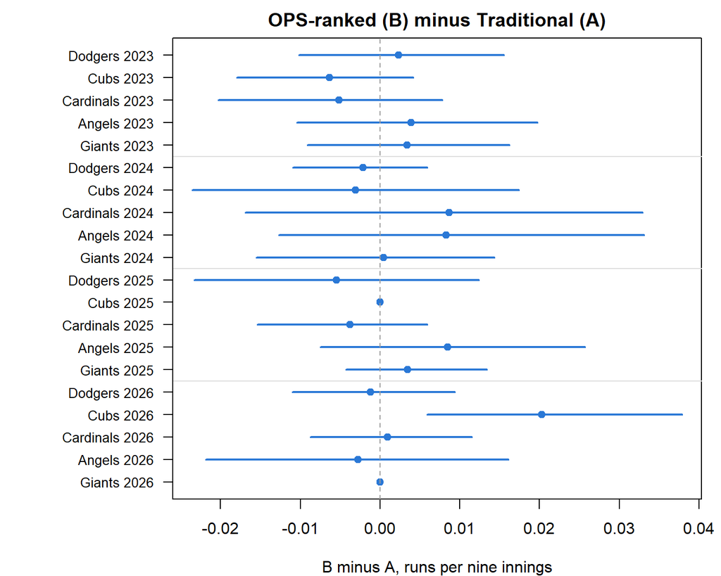

```r
par(mar = c(4, 9, 2, 1))
y <- rev(seq_len(nrow(results)))
plot(results$B_minus_A, y, xlim = range(c(results$ci_low, results$ci_high, 0)), yaxt = "n", pch = 19,
     col = "#2a78d6", xlab = "B minus A, runs per nine innings", ylab = "", main = "OPS-ranked (B) minus Traditional (A)")
segments(results$ci_low, y, results$ci_high, y, col = "#2a78d6", lwd = 2)
abline(v = 0, col = "#9a9a9a", lty = 2)
abline(h = y[results$team == "Giants"][-length(seasons)] - 0.5, col = "#dddddd")
axis(2, at = y, labels = paste(results$team, results$season), las = 1, cex.axis = 0.85)
```

## 7.3 Across Team-Seasons: the Scope’s t-Test

The scope plans a t-test of runs under the two orders. Within one team-season a t-test on simulated games only measures simulation noise (see the Monte Carlo check). The meaningful version treats each team-season as one paired observation: its exact B minus A.

```r
moved <- results %>% filter(slots_moved > 0)
tt_all <- t.test(results$B_minus_A)
tt_moved <- t.test(moved$B_minus_A)
knitr::kable(data.frame(
  sample = c("All 20 team-seasons", "Team-seasons where A and B differ"),
  n = c(nrow(results), nrow(moved)), mean_B_minus_A = c(tt_all$estimate, tt_moved$estimate),
  ci_low = c(tt_all$conf.int[1], tt_moved$conf.int[1]), ci_high = c(tt_all$conf.int[2], tt_moved$conf.int[2]),
  p_value = c(tt_all$p.value, tt_moved$p.value), B_better = c(sum(results$B_minus_A > 0), sum(moved$B_minus_A > 0))),
  digits = 4, caption = "One-sample t-test of B minus A (runs per nine innings) across team-seasons")
```

One-sample t-test of B minus A (runs per nine innings) across team-seasons

| sample | n | mean_B_minus_A | ci_low | ci_high | p_value | B_better |
| --- | --- | --- | --- | --- | --- | --- |
| All 20 team-seasons | 20 | 0.0015 | -0.0014 | 0.0045 | 0.2957 | 10 |
| Team-seasons where A and B differ | 18 | 0.0017 | -0.0016 | 0.0050 | 0.2970 | 10 |

## 7.4 Monte Carlo Check

The same model, simulated game by game: 50,000 nine-inning games per order and team-season. This checks the exact calculation and shows the spread of runs.

```r
simulate_games <- function(p_mat, n_games, model) {
  cum_p <- t(apply(p_mat, 1, cumsum)); cum_p[, nK] <- 1
  runs <- matrix(0L, n_games, 9)
  lead <- rep(1L, n_games)
  for (inn in 1:9) {
    s <- rep(1L, n_games); b <- lead; active <- seq_len(n_games)
    while (length(active) > 0) {
      k <- 1L + rowSums(runif(length(active)) > cum_p[b[active], , drop = FALSE])
      row <- (k - 1L) * 24L + s[active]
      combo <- integer(length(active))
      groups <- split(seq_along(row), row)
      for (g in names(groups)) {
        j <- groups[[g]]
        combo[j] <- sample.int(125L, length(j), replace = TRUE, prob = model$flat[as.integer(g), ])
      }
      runs[active, inn] <- runs[active, inn] + (combo - 1L) %% 5L
      b[active] <- b[active] %% 9L + 1L
      s[active] <- (combo - 1L) %/% 5L + 1L
      active <- active[s[active] != 25L]
    }
    lead <- b
  }
  runs
}

set.seed(2026)
n_games <- 50000
mc <- bind_rows(lapply(main, function(r) {
  ga <- rowSums(simulate_games(r$p[r$a, ], n_games, r$model))
  gb <- if (all(r$a == r$b)) ga else rowSums(simulate_games(r$p[r$b, ], n_games, r$model))
  data.frame(season = r$season, team = r$team, exact_A = r$runs_a, mc_A = mean(ga), exact_B = r$runs_b, mc_B = mean(gb),
             mc_se = sd(ga) / sqrt(n_games), sd_runs_per_game = sd(ga), shutout_A = mean(ga == 0))
}))
knitr::kable(mc, digits = 3, caption = "Exact vs Monte Carlo runs per nine innings")
```

Exact vs Monte Carlo runs per nine innings

| season | team | exact_A | mc_A | exact_B | mc_B | mc_se | sd_runs_per_game | shutout_A |
| --- | --- | --- | --- | --- | --- | --- | --- | --- |
| 2023 | Dodgers | 5.799 | 5.793 | 5.802 | 5.820 | 0.016 | 3.534 | 0.028 |
| 2023 | Cubs | 5.361 | 5.393 | 5.355 | 5.362 | 0.015 | 3.400 | 0.036 |
| 2023 | Cardinals | 5.229 | 5.255 | 5.224 | 5.217 | 0.015 | 3.353 | 0.036 |
| 2023 | Angels | 5.355 | 5.350 | 5.359 | 5.374 | 0.015 | 3.359 | 0.034 |
| 2023 | Giants | 4.655 | 4.643 | 4.658 | 4.659 | 0.014 | 3.119 | 0.052 |
| 2024 | Dodgers | 5.737 | 5.766 | 5.735 | 5.725 | 0.016 | 3.517 | 0.027 |
| 2024 | Cubs | 4.618 | 4.609 | 4.615 | 4.624 | 0.014 | 3.129 | 0.054 |
| 2024 | Cardinals | 4.573 | 4.578 | 4.581 | 4.570 | 0.014 | 3.080 | 0.053 |
| 2024 | Angels | 4.038 | 4.042 | 4.047 | 4.063 | 0.013 | 2.850 | 0.072 |
| 2024 | Giants | 4.188 | 4.191 | 4.188 | 4.196 | 0.013 | 2.922 | 0.067 |
| 2025 | Dodgers | 5.466 | 5.459 | 5.461 | 5.446 | 0.015 | 3.384 | 0.031 |
| 2025 | Cubs | 5.019 | 5.001 | 5.019 | 5.001 | 0.014 | 3.230 | 0.042 |
| 2025 | Cardinals | 4.575 | 4.582 | 4.571 | 4.551 | 0.014 | 3.082 | 0.054 |
| 2025 | Angels | 4.640 | 4.659 | 4.649 | 4.657 | 0.014 | 3.114 | 0.051 |
| 2025 | Giants | 4.493 | 4.492 | 4.497 | 4.505 | 0.014 | 3.066 | 0.056 |
| 2026 | Dodgers | 5.550 | 5.566 | 5.549 | 5.552 | 0.016 | 3.501 | 0.032 |
| 2026 | Cubs | 5.396 | 5.392 | 5.417 | 5.406 | 0.015 | 3.423 | 0.035 |
| 2026 | Cardinals | 3.900 | 3.899 | 3.901 | 3.904 | 0.013 | 2.836 | 0.080 |
| 2026 | Angels | 4.148 | 4.147 | 4.145 | 4.146 | 0.013 | 2.933 | 0.069 |
| 2026 | Giants | 4.603 | 4.599 | 4.603 | 4.599 | 0.014 | 3.064 | 0.051 |

```r
stopifnot(all(abs(mc$mc_A - mc$exact_A) < 4 * mc$mc_se), all(abs(mc$mc_B - mc$exact_B) < 4 * mc$mc_se))
```

- Every Monte Carlo mean is within 2.1 standard errors of the exact value.
- Runs in one game have a standard deviation of about 3.2. With *n* simulated games, the standard error of a difference of two means is about 3.2 × √(2/*n*): 0.03 runs at 20,000 games. Differences of a few hundredths of a run need the exact calculation or millions of games.

## 7.5 How Much Can Order Matter?

To show the model does respond to batting order, the same nine hitters sorted by OPS from high to low and from low to high. `gap_prev_ops` sorts by previous-season OPS, the information A and B use; `gap_same_ops` sorts by that season’s OPS, which is hindsight.

```r
chars_same <- league %>% filter(season %in% seasons) %>% add_rates()
order_scale <- bind_rows(lapply(main, function(r) {
  d <- filter(hitters, season == r$season, team == r$team)
  ops_same <- chars_same$ops[match(paste(d$season, d$batter_id), paste(chars_same$season, chars_same$batter_id))]
  best_prev <- order(-d$ops); best_same <- order(-ops_same)
  data.frame(season = r$season, team = r$team,
             gap_prev_ops = expected_runs(r$p[best_prev, ], r$model) - expected_runs(r$p[rev(best_prev), ], r$model),
             gap_same_ops = expected_runs(r$p[best_same, ], r$model) - expected_runs(r$p[rev(best_same), ], r$model))
})) %>% mutate(gap_same_per_162 = 162 * gap_same_ops)
knitr::kable(order_scale, digits = 3, caption = "Runs per nine innings, best-first minus worst-first")
```

Runs per nine innings, best-first minus worst-first

| season | team | gap_prev_ops | gap_same_ops | gap_same_per_162 |
| --- | --- | --- | --- | --- |
| 2023 | Dodgers | 0.138 | 0.188 | 30.511 |
| 2023 | Cubs | 0.014 | 0.075 | 12.214 |
| 2023 | Cardinals | 0.046 | 0.082 | 13.343 |
| 2023 | Angels | 0.119 | 0.157 | 25.406 |
| 2023 | Giants | -0.007 | 0.097 | 15.762 |
| 2024 | Dodgers | 0.102 | 0.124 | 20.163 |
| 2024 | Cubs | 0.031 | 0.061 | 9.900 |
| 2024 | Cardinals | 0.026 | 0.101 | 16.416 |
| 2024 | Angels | -0.043 | 0.088 | 14.334 |
| 2024 | Giants | 0.050 | 0.096 | 15.615 |
| 2025 | Dodgers | 0.076 | 0.169 | 27.333 |
| 2025 | Cubs | 0.060 | 0.094 | 15.177 |
| 2025 | Cardinals | 0.098 | 0.102 | 16.591 |
| 2025 | Angels | 0.004 | 0.096 | 15.531 |
| 2025 | Giants | 0.069 | 0.081 | 13.199 |
| 2026 | Dodgers | 0.044 | 0.065 | 10.478 |
| 2026 | Cubs | 0.056 | 0.090 | 14.660 |
| 2026 | Cardinals | 0.038 | 0.091 | 14.699 |
| 2026 | Angels | 0.100 | 0.131 | 21.248 |
| 2026 | Giants | 0.057 | 0.057 | 9.238 |

- With hindsight, reversing the order costs 0.06-0.19 runs per game, about 9-31 runs over a season, so the model does detect order effects.
- Sorted by previous-season OPS, the gap ranges from -0.04 to 0.14 runs per game, and in 2 team-seasons the reversed order even scores more. How well last season predicts this one limits what any order rule can gain.

## 7.6 Why A and B Are So Close

Moving a hitter changes runs mainly by changing how often he bats. Each hitter is valued in runs above an average plate appearance, using run values for each outcome from the model’s run expectancy.

```r
# Expected plate appearances per batting slot in a nine-inning game.
pa_by_slot <- function(p_mat, model) {
  steps <- lapply(1:9, function(i) batter_step(p_mat[i, ], model))
  inn <- lapply(1:9, function(j) {
    v <- c(1, numeric(23)); b <- j; pa <- numeric(9); nxt <- numeric(9)
    while (sum(v) > 1e-12) {
      pa[b] <- pa[b] + sum(v)
      w <- drop(v %*% steps[[b]]$T)
      b <- b %% 9 + 1
      nxt[b] <- nxt[b] + w[25]
      v <- w[1:24]
    }
    list(pa = pa, nxt = nxt)
  })
  L <- t(sapply(inn, `[[`, "nxt")); P <- t(sapply(inn, `[[`, "pa"))
  lead <- c(1, numeric(8)); total <- numeric(9)
  for (t in 1:9) { total <- total + drop(lead %*% P); lead <- drop(lead %*% L) }
  total
}

# Run value of each outcome: change in run expectancy plus runs scored, averaged over the states where PAs happen.
run_values <- t(sapply(seasons, function(y) {
  m <- models[[as.character(y)]]; re <- re_by_season[[as.character(y)]]
  setNames(sapply(seq_len(nK), function(k) sum(re$freq * (drop(m$M[[k]] %*% c(re$re, 0)) + m$ER[[k]] - re$re))), categories)
}))
rownames(run_values) <- seasons
knitr::kable(run_values, digits = 3, caption = "Run value of each outcome, relative to an average plate appearance")
```

Run value of each outcome, relative to an average plate appearance

|  | 1B | 2B | 3B | HR | BB | ROE | K | OUT |
| --- | --- | --- | --- | --- | --- | --- | --- | --- |
| 2023 | 0.475 | 0.751 | 0.991 | 1.413 | 0.349 | 0.459 | -0.287 | -0.280 |
| 2024 | 0.463 | 0.730 | 0.985 | 1.400 | 0.341 | 0.442 | -0.266 | -0.256 |
| 2025 | 0.457 | 0.724 | 0.964 | 1.401 | 0.341 | 0.465 | -0.270 | -0.258 |
| 2026 | 0.471 | 0.739 | 0.975 | 1.413 | 0.350 | 0.475 | -0.275 | -0.263 |

```r
slot_pa <- t(sapply(main, function(r) pa_by_slot(r$p[r$a, ], r$model)))
knitr::kable(t(colMeans(slot_pa)) %>% `colnames<-`(paste("slot", 1:9)), digits = 2,
             caption = "Plate appearances per game by slot (order A, average over team-seasons)")
```

Plate appearances per game by slot (order A, average over team-seasons)

| slot 1 | slot 2 | slot 3 | slot 4 | slot 5 | slot 6 | slot 7 | slot 8 | slot 9 |
| --- | --- | --- | --- | --- | --- | --- | --- | --- |
| 4.76 | 4.65 | 4.54 | 4.44 | 4.33 | 4.22 | 4.11 | 4 | 3.88 |

```r
pa_effect <- bind_rows(lapply(main, function(r) {
  slot_a <- match(seq_len(9), r$a); slot_b <- match(seq_len(9), r$b)
  mv <- which(slot_a != slot_b)
  if (length(mv) == 0) return(NULL)
  pa_a <- pa_by_slot(r$p[r$a, ], r$model)
  value <- drop(r$p %*% run_values[as.character(r$season), ])
  data.frame(season = r$season, team = r$team, PA_effect = sum(value[mv] * (pa_a[slot_b[mv]] - pa_a[slot_a[mv]])))
})) %>% left_join(results %>% select(season, team, exact_B_minus_A = B_minus_A), by = c("season", "team")) %>%
  mutate(sequencing_effect = exact_B_minus_A - PA_effect)
knitr::kable(pa_effect, digits = 4, caption = "B minus A split into plate appearances and sequencing (runs per game)")
```

B minus A split into plate appearances and sequencing (runs per game)

| season | team | PA_effect | exact_B_minus_A | sequencing_effect |
| --- | --- | --- | --- | --- |
| 2023 | Dodgers | 0.0069 | 0.0024 | -0.0046 |
| 2023 | Cubs | -0.0035 | -0.0063 | -0.0029 |
| 2023 | Cardinals | -0.0013 | -0.0052 | -0.0039 |
| 2023 | Angels | 0.0108 | 0.0039 | -0.0069 |
| 2023 | Giants | -0.0033 | 0.0034 | 0.0067 |
| 2024 | Dodgers | 0.0001 | -0.0021 | -0.0023 |
| 2024 | Cubs | 0.0059 | -0.0030 | -0.0089 |
| 2024 | Cardinals | -0.0001 | 0.0087 | 0.0088 |
| 2024 | Angels | -0.0290 | 0.0083 | 0.0373 |
| 2024 | Giants | -0.0067 | 0.0004 | 0.0071 |
| 2025 | Dodgers | 0.0004 | -0.0055 | -0.0059 |
| 2025 | Cardinals | -0.0037 | -0.0038 | -0.0001 |
| 2025 | Angels | 0.0068 | 0.0085 | 0.0017 |
| 2025 | Giants | 0.0030 | 0.0035 | 0.0005 |
| 2026 | Dodgers | 0.0041 | -0.0012 | -0.0053 |
| 2026 | Cubs | 0.0123 | 0.0203 | 0.0080 |
| 2026 | Cardinals | 0.0024 | 0.0010 | -0.0015 |
| 2026 | Angels | -0.0026 | -0.0027 | -0.0001 |

- Each slot down the order bats about 0.11 fewer times per game, about 18 plate appearances over a season. Swapping two hitters who are 0.05 runs per PA apart changes about 0.11 × 0.05 ≈ 0.005 runs per game.
- The rest is sequencing: who bats ahead of whom, for example a high-OBP hitter in front of a power hitter. It is of the same small size and often has the opposite sign.
- The scope’s Traditional rule already bats the highest-OBP hitter first, which is close to what analysts recommend. It is not the old-style lineup with a fast, low-OBP leadoff hitter and the best hitter third, so B has little left to improve.

## 7.7 Stability Checks

Each row changes one judgment call and recomputes B minus A for all 20 team-seasons with the same nine hitters.

```r
chars_two <- bind_rows(lapply(seasons, function(y) pooled(c(y - 2, y - 1)) %>% mutate(season = y)))
scenario <- function(name, chars, b_rule = ops_order, notebook = FALSE) {
  h <- make_hitters(chars)
  stopifnot(!anyNA(h$ops))
  bind_rows(lapply(seq_len(nrow(team_seasons)), function(i) {
    m <- if (notebook) notebook_model else models[[as.character(team_seasons$season[i])]]
    r <- run_team(get_nine(h, i), m, b_rule)
    data.frame(scenario = name, season = r$season, team = r$team, slots_moved = sum(r$a != r$b),
               runs_A = r$runs_a, B_minus_A = r$runs_b - r$runs_a)
  }))
}
sensitivity <- bind_rows(
  scenario("Main: previous-season characteristics", chars_main),
  scenario("Same-season characteristics (hindsight, as in the PM's notebook)", chars_same),
  scenario("Two prior seasons pooled", chars_two),
  scenario("B = all nine by OPS (page-3 table)", chars_main, ops_all_order),
  scenario("Fixed base-running rules from the PM's notebook", chars_main, notebook = TRUE))
write.csv(sensitivity, "processed/simulation_sensitivity.csv", row.names = FALSE)
sens_summary <- sensitivity %>% group_by(scenario = factor(scenario, unique(scenario))) %>%
  summarise(orders_differ = sum(slots_moved > 0), mean_runs_A = mean(runs_A), mean_B_minus_A = mean(B_minus_A),
            min = min(B_minus_A), max = max(B_minus_A), B_better = sum(B_minus_A > 0), .groups = "drop")
knitr::kable(sens_summary, digits = 4, caption = "B minus A (runs per nine innings) across 20 team-seasons, by scenario")
```

B minus A (runs per nine innings) across 20 team-seasons, by scenario

| scenario | orders_differ | mean_runs_A | mean_B_minus_A | min | max | B_better |
| --- | --- | --- | --- | --- | --- | --- |
| Main: previous-season characteristics | 18 | 4.8672 | 0.0015 | -0.0063 | 0.0203 | 10 |
| Same-season characteristics (hindsight, as in the PM’s notebook) | 17 | 4.8980 | -0.0051 | -0.0229 | 0.0055 | 7 |
| Two prior seasons pooled | 16 | 4.8648 | -0.0014 | -0.0157 | 0.0122 | 5 |
| B = all nine by OPS (page-3 table) | 18 | 4.8672 | -0.0004 | -0.0202 | 0.0181 | 8 |
| Fixed base-running rules from the PM’s notebook | 18 | 4.6707 | -0.0002 | -0.0158 | 0.0157 | 9 |

- The largest B minus A in absolute value in any scenario is 0.023 runs per game, about 3.7 runs over a season.

```r
lineup_out <- bind_rows(lapply(main, function(r) {
  d <- filter(hitters, season == r$season, team == r$team) %>%
    left_join(candidates %>% select(season, batter_id, team, char_source, char_pa), by = c("season", "team", "batter_id"))
  data.frame(d, r$p, slot_A = match(seq_len(9), r$a), slot_B = match(seq_len(9), r$b), check.names = FALSE)
}))
write.csv(lineup_out, "processed/simulation_lineups.csv", row.names = FALSE, fileEncoding = "UTF-8")
write.csv(pa_rows %>% count(season, category, from, combo) %>%
            mutate(next_state = (combo - 1) %/% 5 + 1, runs = (combo - 1) %% 5) %>% select(-combo),
          "processed/simulation_transitions.csv", row.names = FALSE)
```

# 8 Conclusion

- With the same nine hitters, the OPS-ranked order (B) and the Traditional order (A) produce practically the same expected runs in all 20 team-seasons.
  - In 2 team-seasons the two rules give the identical lineup.
  - Where they differ, B minus A is -0.0063 to 0.0203 runs per game, or -1.0 to 3.3 runs over 162 games.
  - 1 of 18 bootstrap intervals exclude zero (Cubs 2026), about what chance alone gives with 18 intervals at the 95% level (0.9 expected).
  - Across team-seasons the mean B minus A is 0.0015 runs per game (95% CI -0.0014 to 0.0045, *p* = 0.30).
- No stability check changes this: the largest absolute difference in any scenario is 0.023 runs per game, including the PM’s same-season characteristics and fixed base-running rules.
- The model does respond to order: with hindsight, reversing a lineup costs 0.06-0.19 runs per game. Rearranging two to five hitters within the top five is too small a change to matter.
- The answer to the research question: neither order produces meaningfully more runs. Who is in the lineup matters far more than which of these two orders is used.

**Limitations.** Baserunning is the same for every hitter and team within a season. Steals, pickoffs, and wild pitches between plate appearances are left out. Opposing pitchers are not modeled. Nine full innings are played every game. These affect A and B in the same way, so they matter much less for the difference than for the run totals.